# Campus Placement Analysis for Jain University

#### 0.2.1.11 Were students from any particular secondary and higher secondary school board preferred?

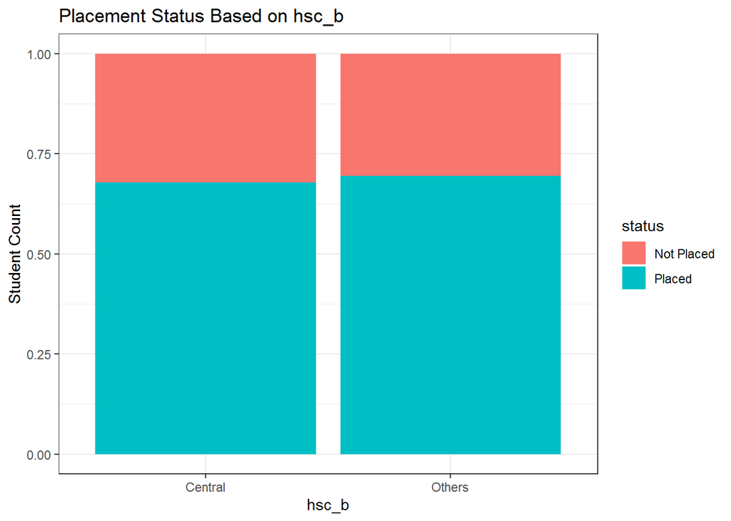

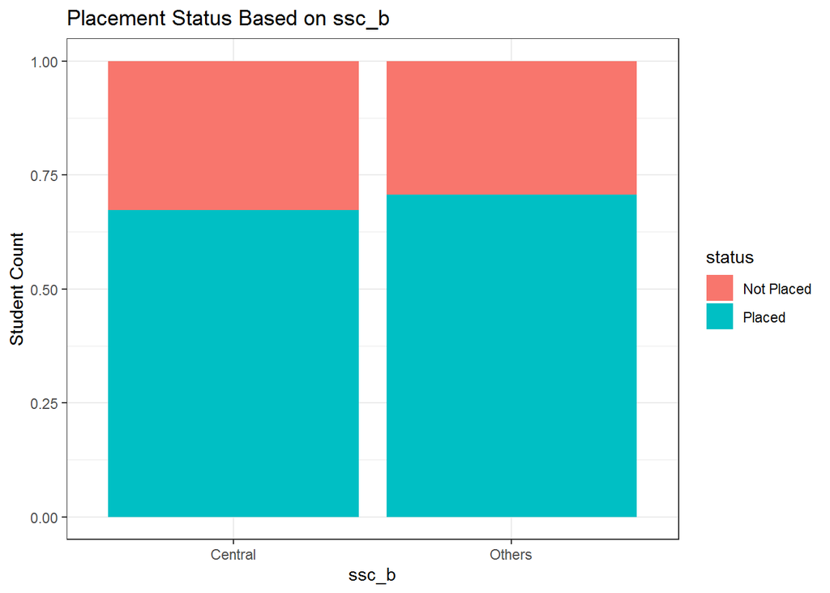

**Remark:** There does not seem to be any visual evidence to suggest any particular is preferred than the other.

*Thus far the visual analysis suggests that test scores from all secondary and post-secondary levels were taken into account when deciding which student/candidate to hire.*

*Now let us explore these test scores with respect to the MBA specializations and if one group fared better than the other in terms of their work experience.*

#### 0.2.1.12 How does the MBA score vary over different specializations?

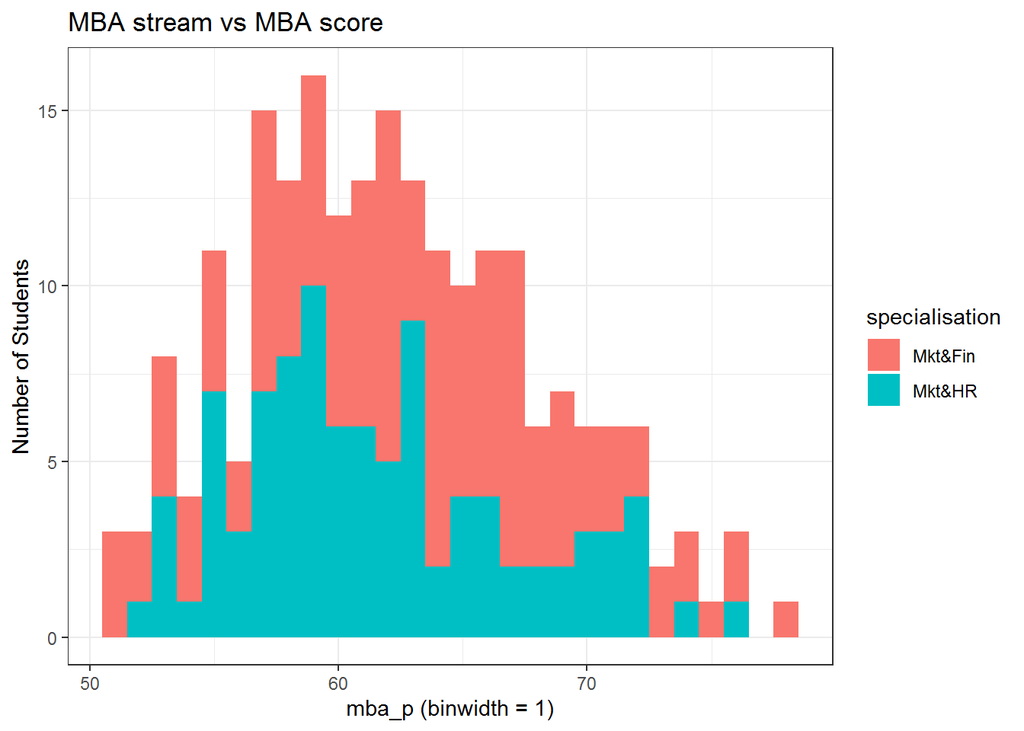

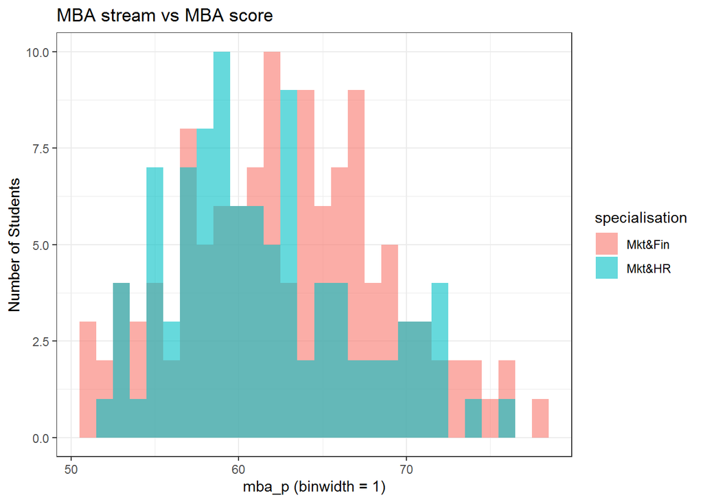

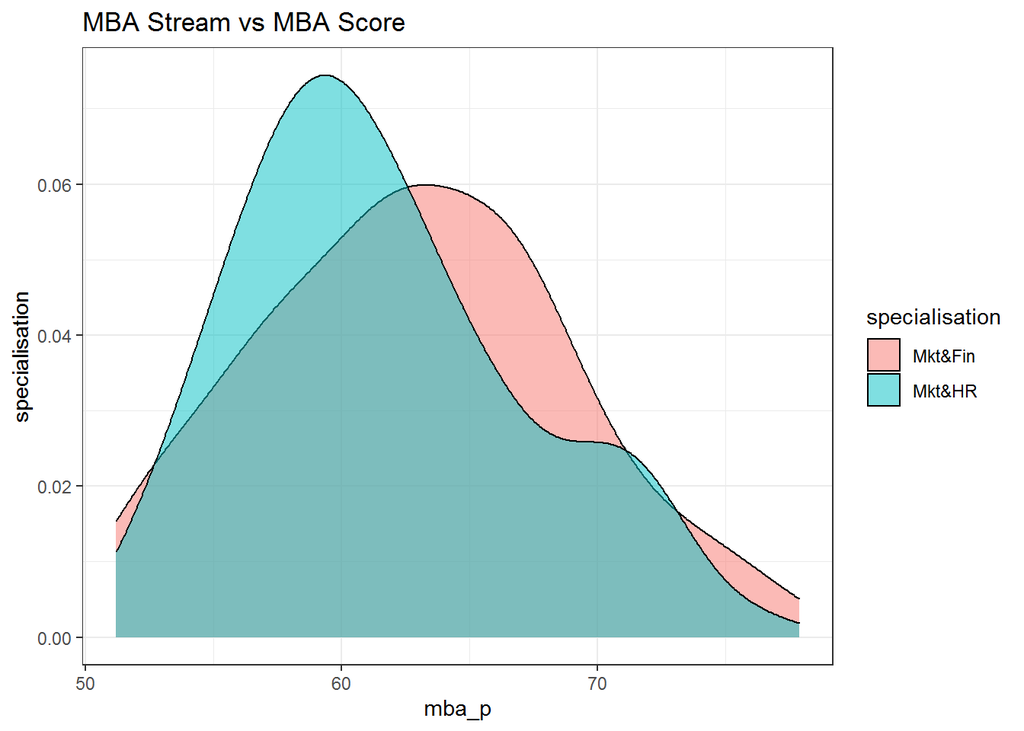

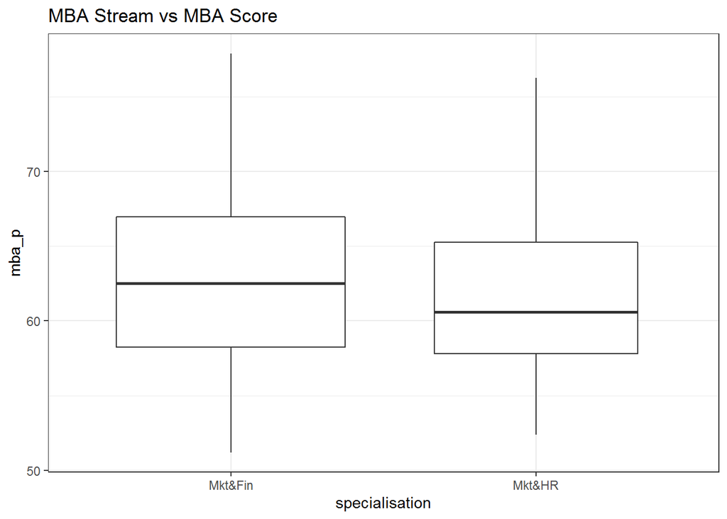

**Remark:** The trend between MBA test scores and specializations is not clear from the histograms. But the density and box plots show that more students specializing Mkt&HR had lower scores and more students specializingin Mkt&Fin had higher scores. We also see from the boxplot that students in Mkt&Fin had a higher median score than those in Mkt&HR. Median score for Mkt&Fin students is around 63, and that for Mkt&HR students is around 61. For the second group, the distribution is skewed to the right.

#### 0.2.1.13 How does the employement test score vary for MBA students based on their specialization?

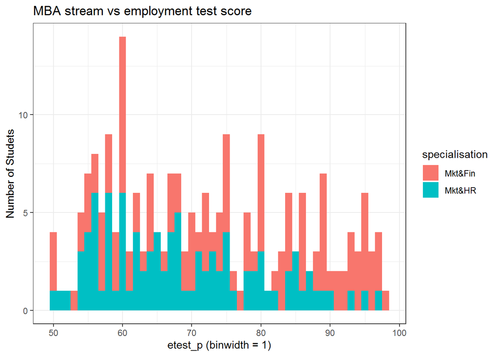

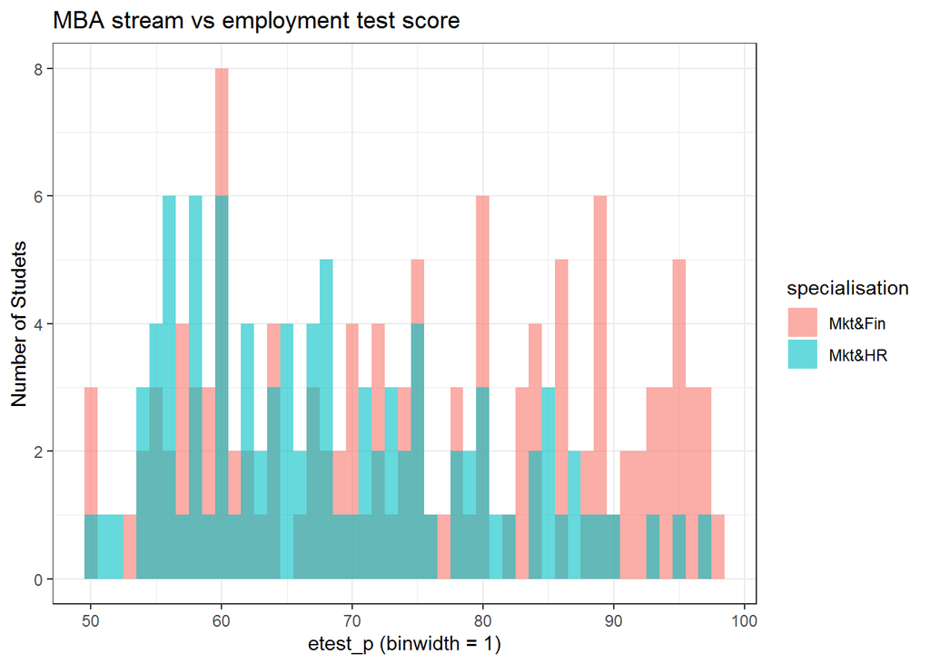

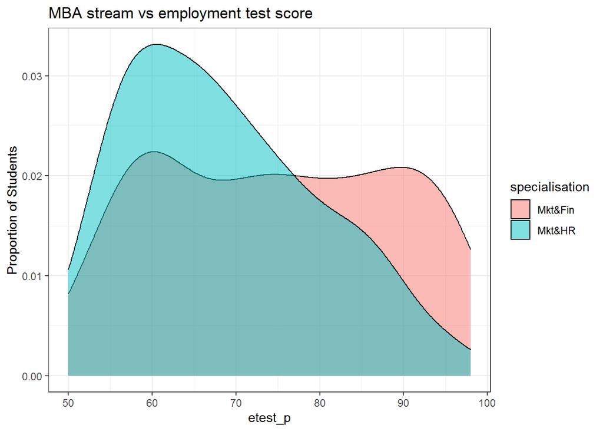

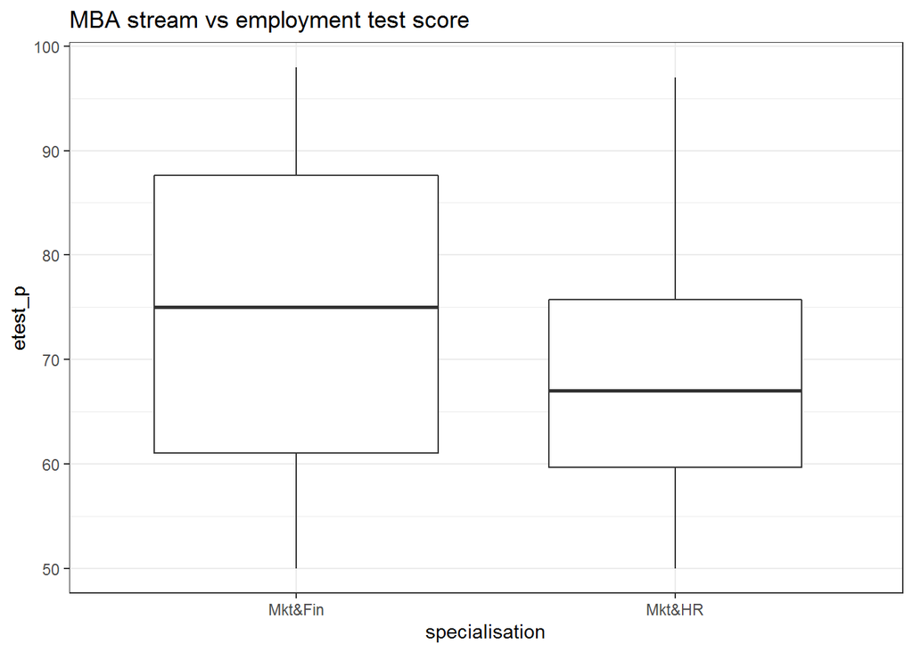

**Remark:** Based on the density curve and box plot, we see that employement test scores for students in Mkt&Fin is more uniformly distributed, with a median score of 75. For Mkt&HR students, the test scores are skewed to the right, with a median score of 67.

#### 0.2.1.14 What is the degree test score for students according to their MBA specialization?

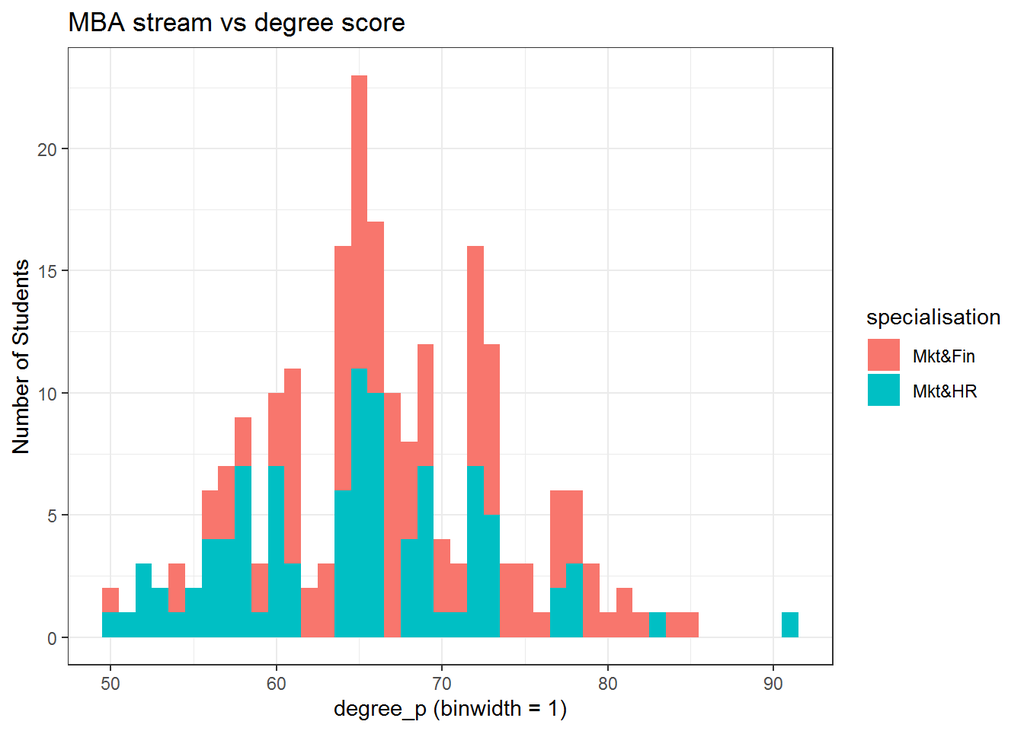

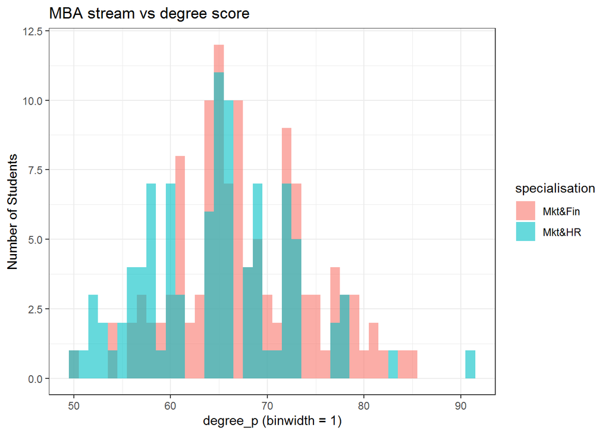

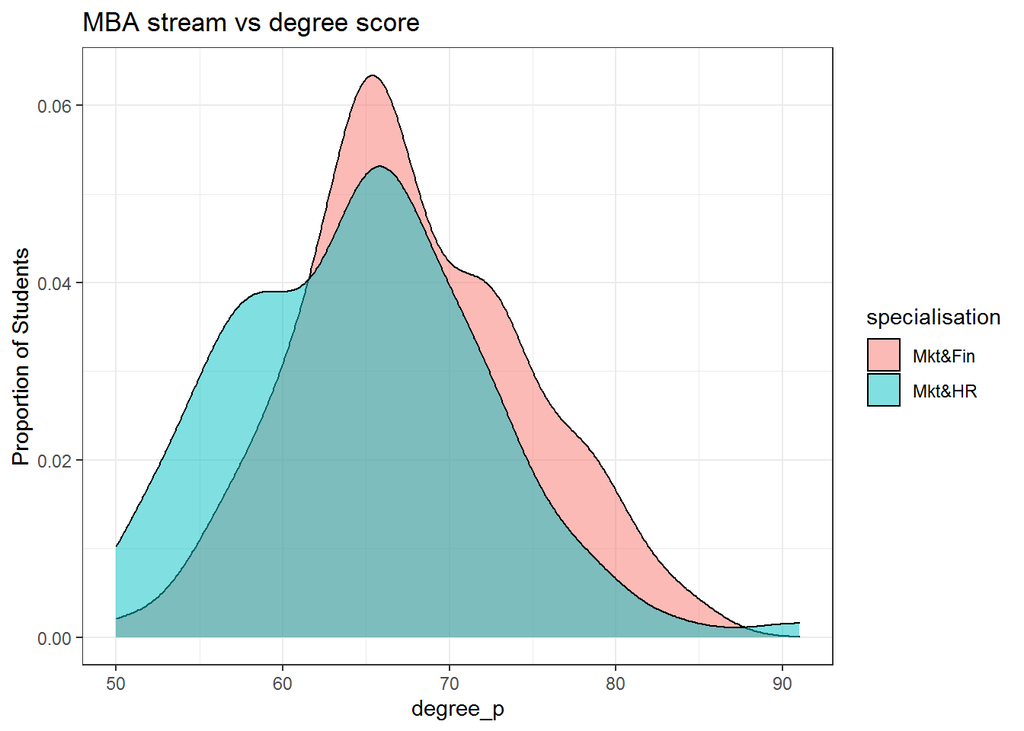

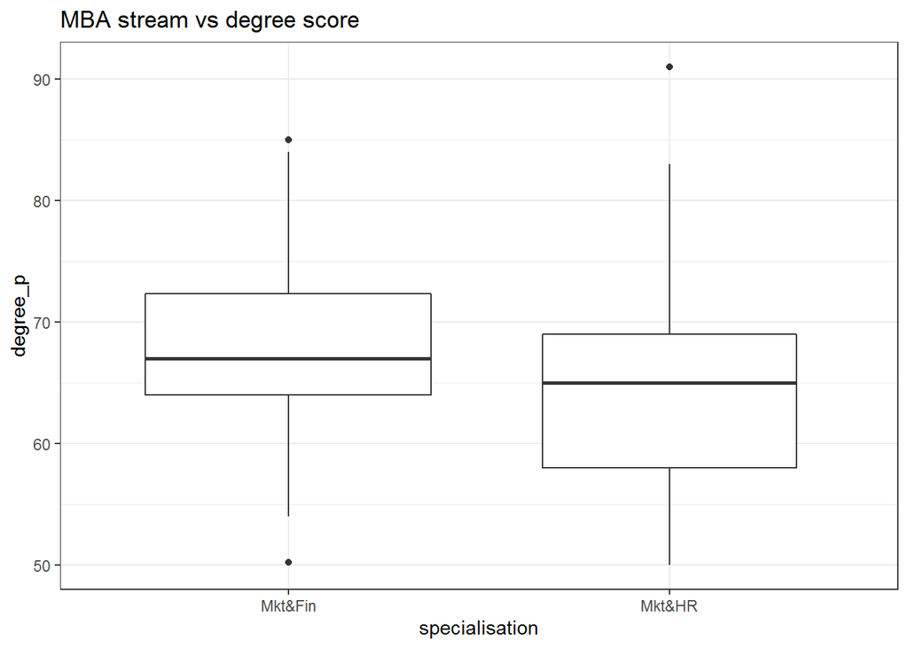

**Remark:** The histogram and density plots show that more students with Mkt&HR had lower degree scores, and more students specializing in Mkt&Fin scored higher. Based on the box plot, median degree test score for Mkt&Fin is 67 and that for Mkt&HR is 65. Even though the median scores for both specializations are almost the same, the scores for Mkt&Fin are skewed right and those for Mkt&HR are skewed left. Which means, more Mkt&Fin students scored in the second quartile (64 - 67), and more Mkt&HR students scored in the third quartile (65 - 69).

#### 0.2.1.15 What is the higher secondary test score for students according to their MBA specialization?

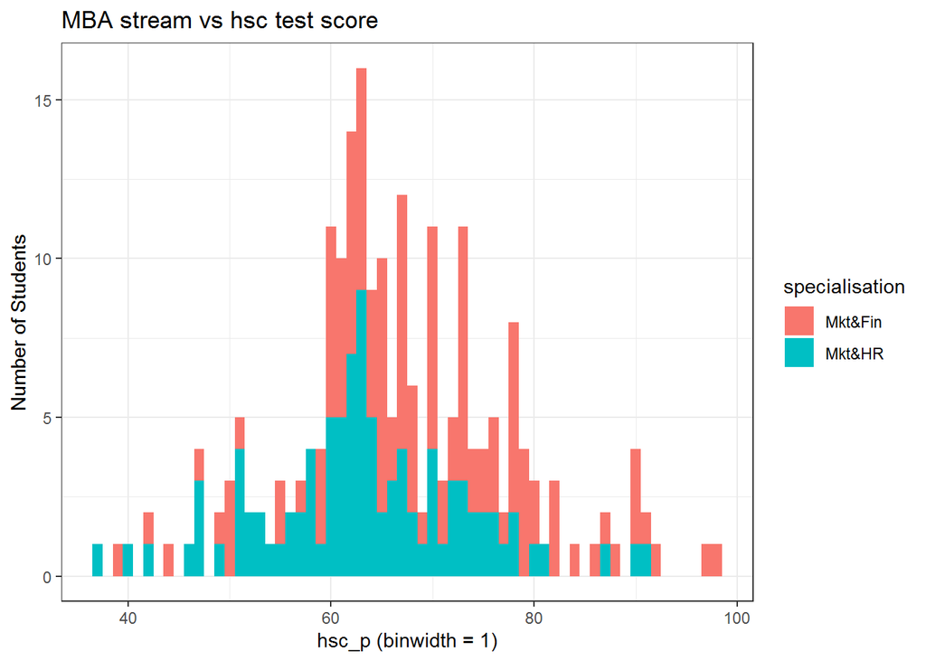

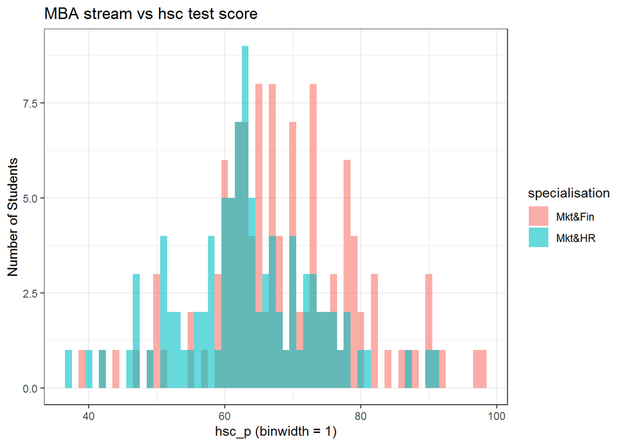

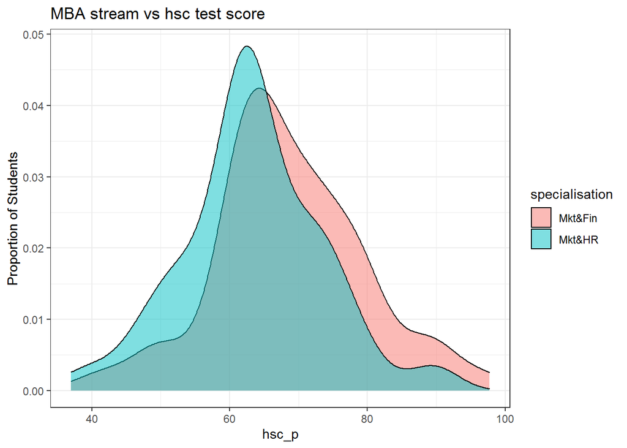

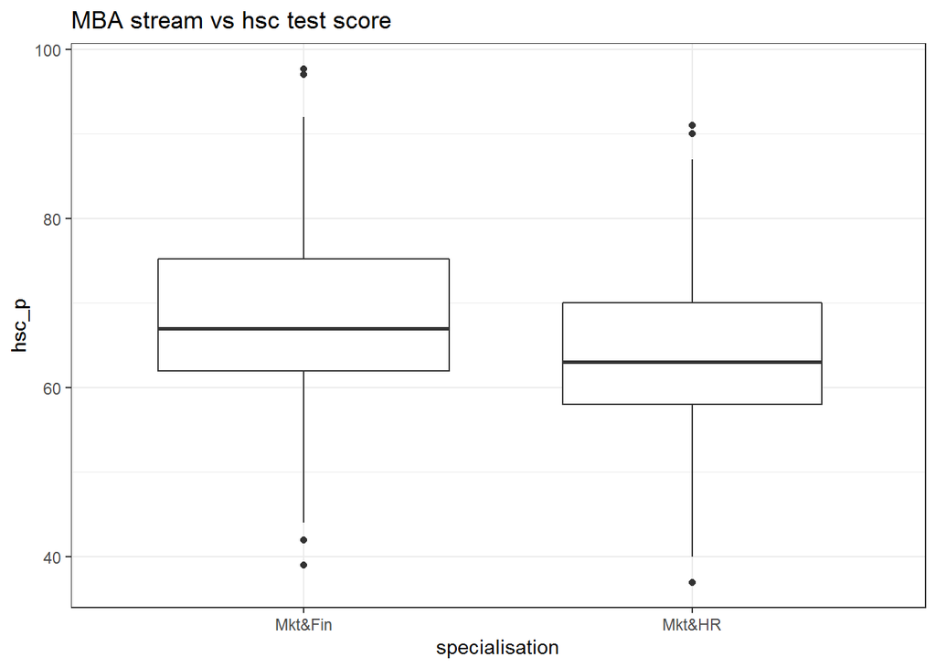

#### 0.2.1.16 What is the secondary test score for students according to their MBA specialization?

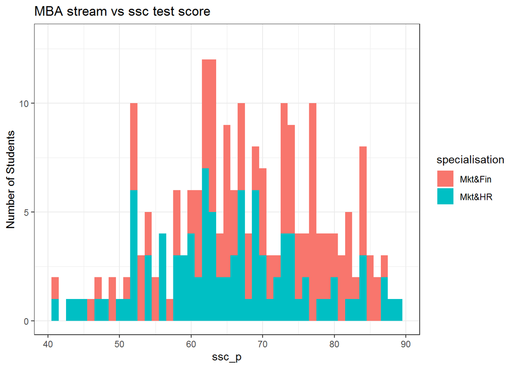

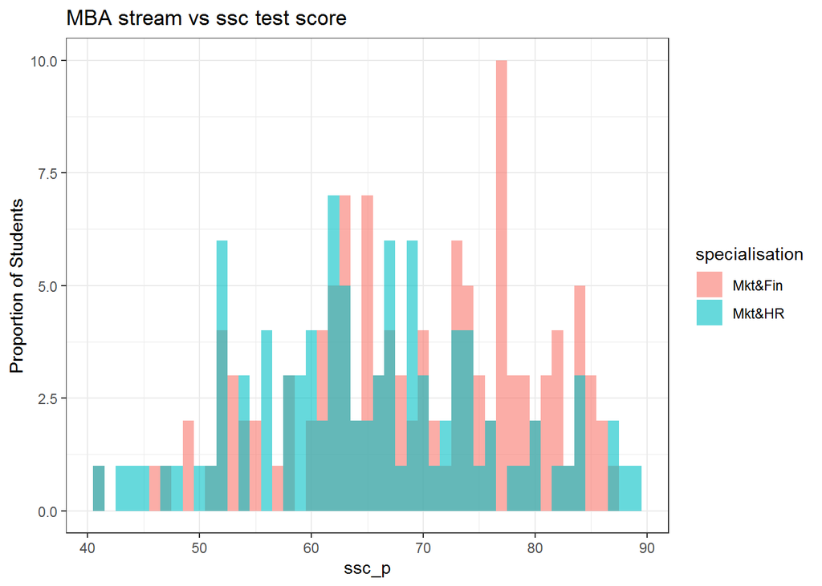

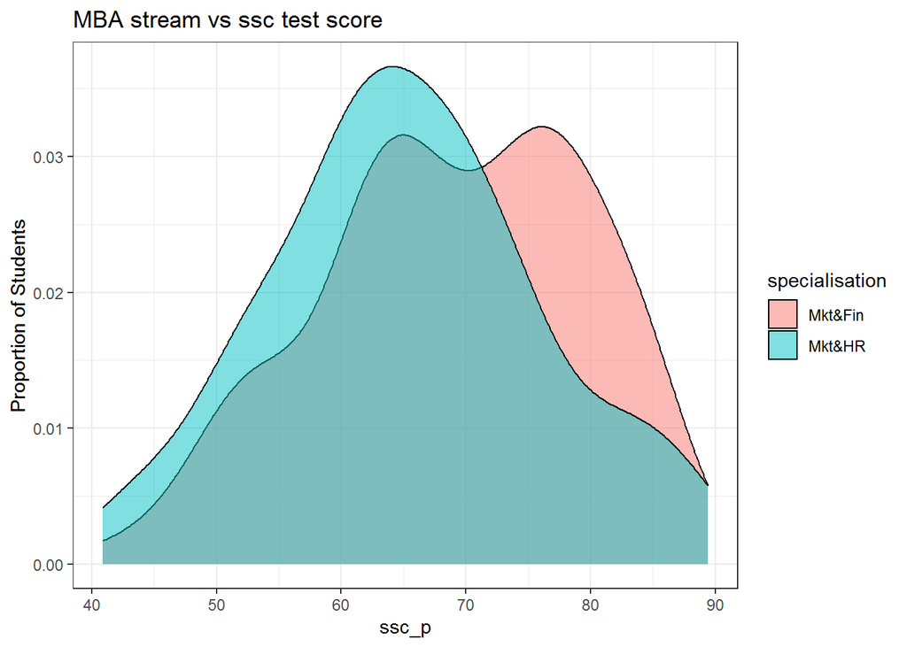

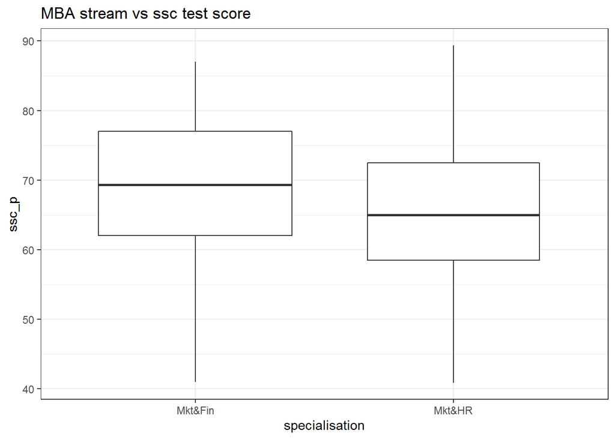

**Remark:** The density curve and box plot show that the ssc test score distribution for Mkt&Fin students are skewed left, with a median of 69. And the ssc test score distribution for Mkt&HR students are almost symmetrical, with a median of 65.

#### 0.2.1.17 Is there a connection between MBA stream and work experience?

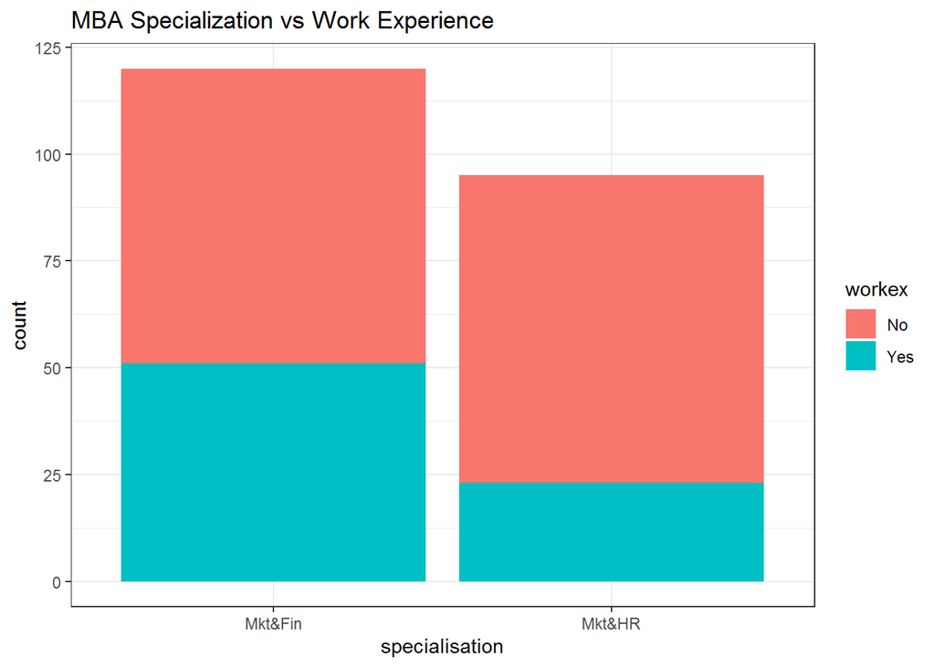

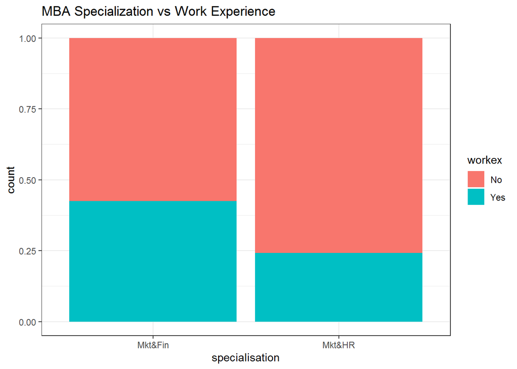

**Remark:** The bar graph on the left shows there are more students specializing in Mkt&Fin than in Mkt&HR. From the proportion bar graph on the right we see that more students in Mkt&Fin with work experience than those in the Mkt&HR specialization.

#### 0.2.1.18 Is there a connection between MBA test score and work experience?

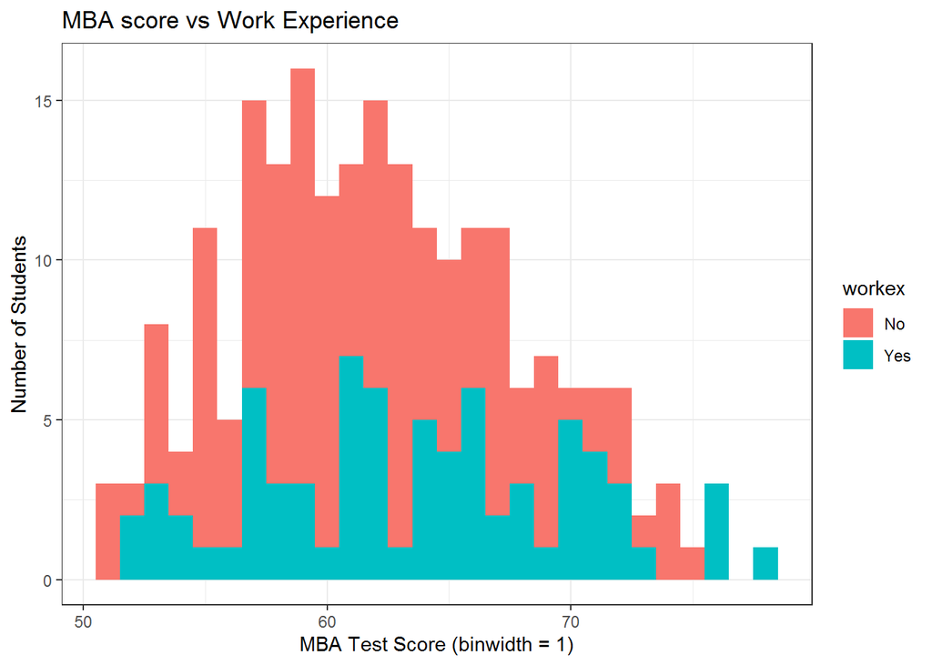

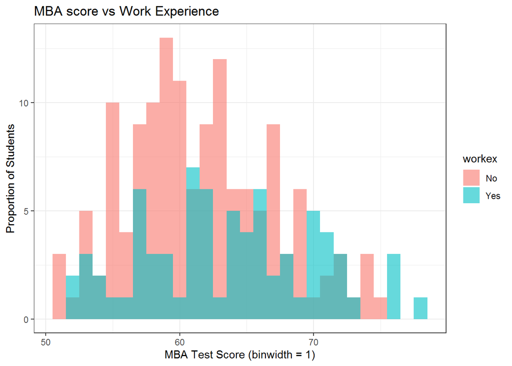

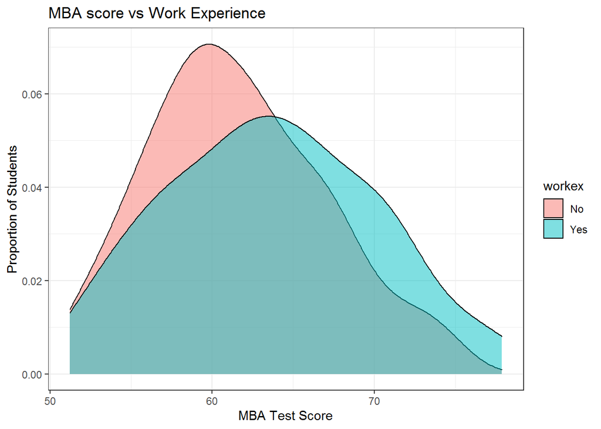

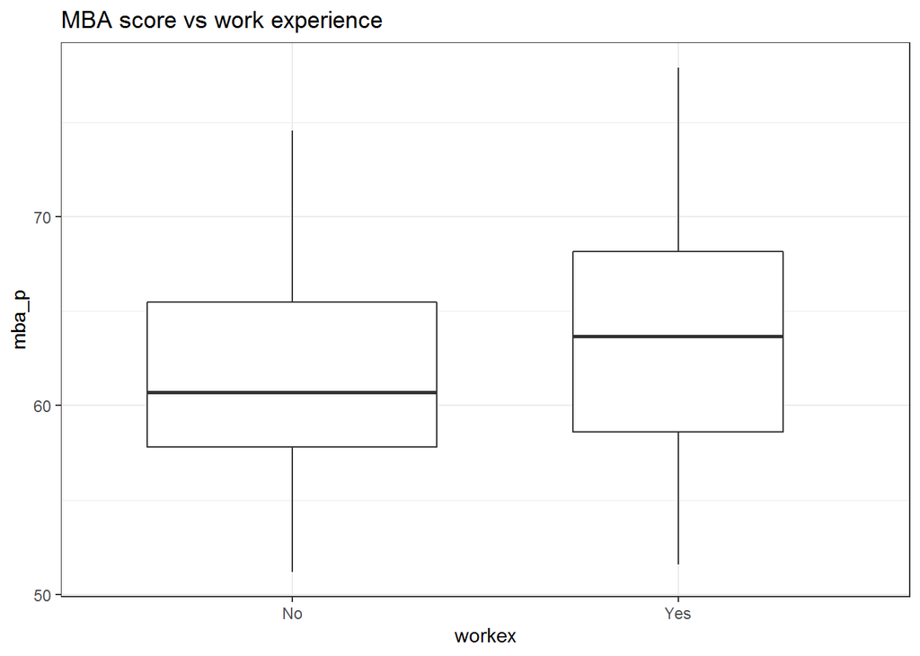

**Remark:** Students with work exprience generally have higher MBA score. From the density plot and box plot we see that test scores for students without job experience is skewed right, and test scores for students with work experience is symmetric. The median test score for students with work experience is around 64. The median test score for students without work experience is around 61.

*We previously found that more students specializing in Mkt&Fin were hired than those in Mkt&HR. Based on the analysis of the test scores and work experiences of students with respect to their MBA specialization, we found that more students from Mkt&Fin had work experience and higher secondar and post-secondary test scores than those in Mkt&HR.*

*Next, it is reasonable to wonder if gender played any role in the hiring process.*

#### 0.2.1.19 Did gender play a role in the hiring process?

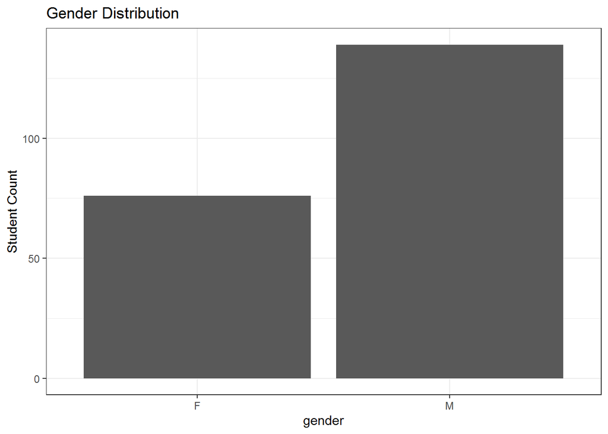

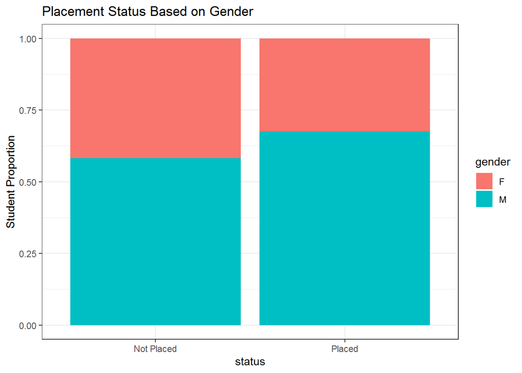

#### 0.2.1.20 What is the work experience according to the gender?

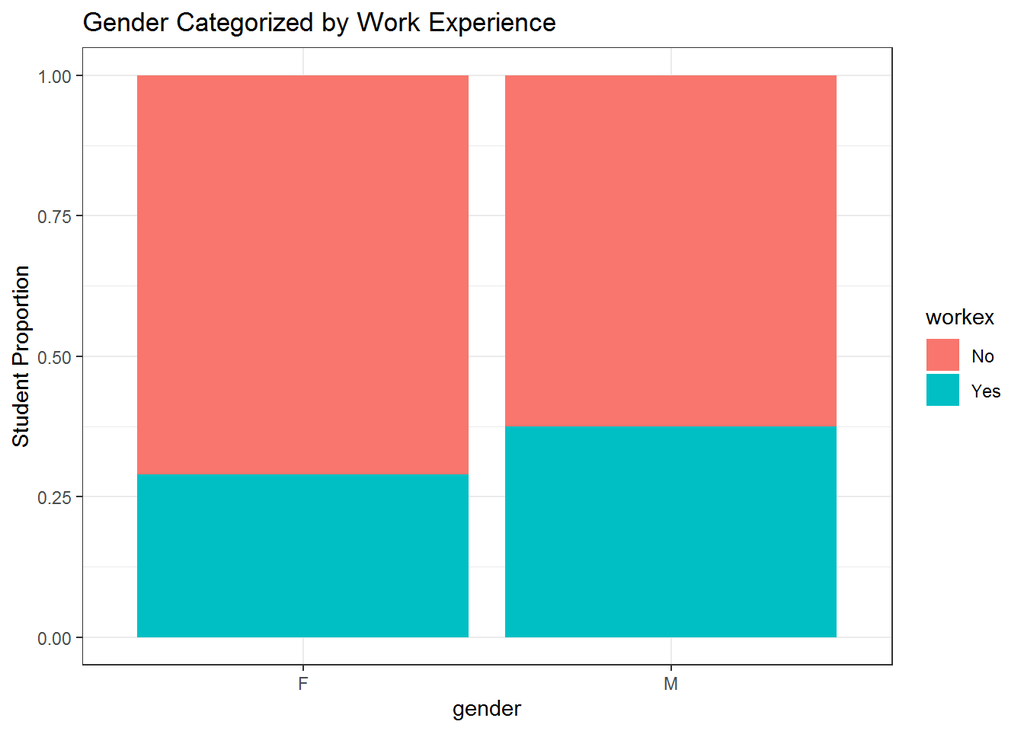

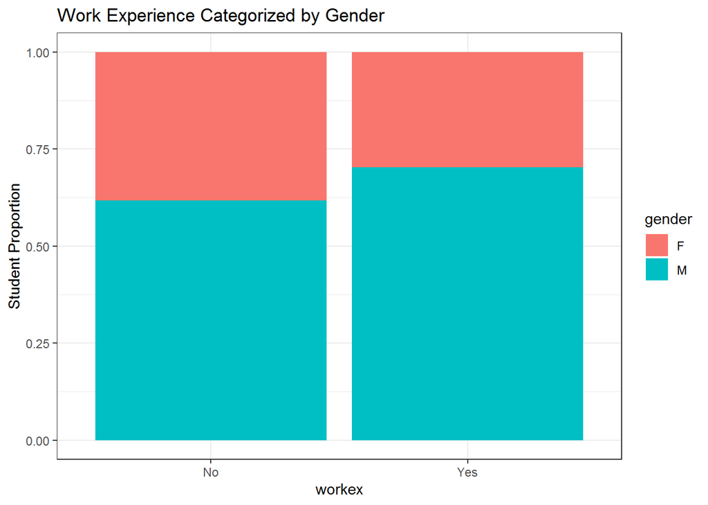

**Remark:** The proportion bar plot on the left shows that there are more male students with work experience than female.

From the proportion bar plot on the right we see that among those students with work experience, around 70% are male and 30% are female. In case of those students without work experience, around 62% are male and 38% are female.

#### 0.2.1.21 Is there a preference for MBA specialization according to gender?

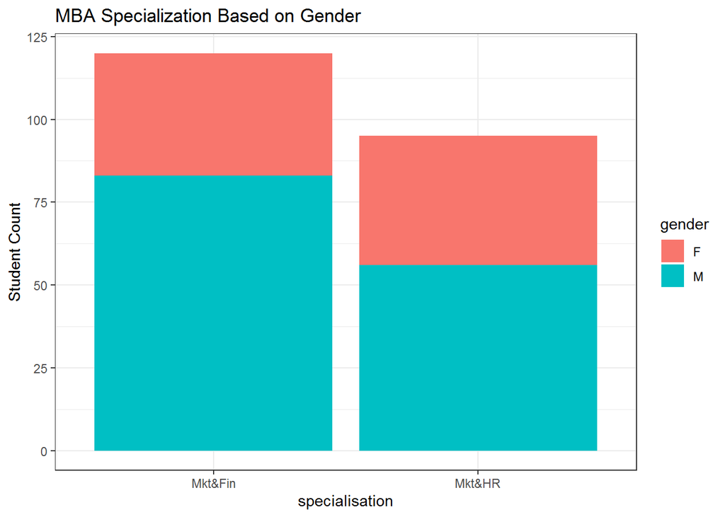

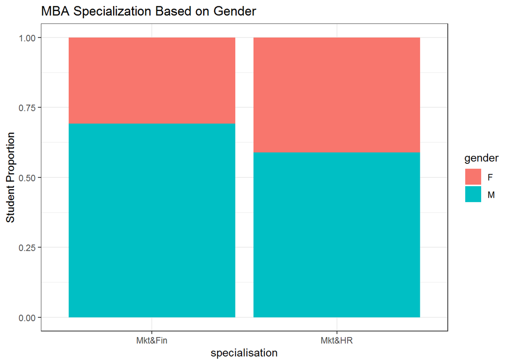

**Remark:** The proportion bar plot on the right shows that more female students specialized in Mkt&HR and more male students specialized in Mkt&Fin.

#### 0.2.1.22 How did students from each gender perform on the MBA test?

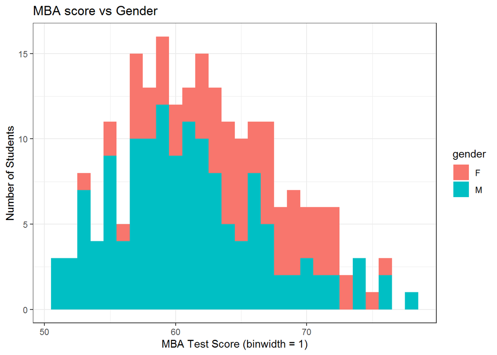

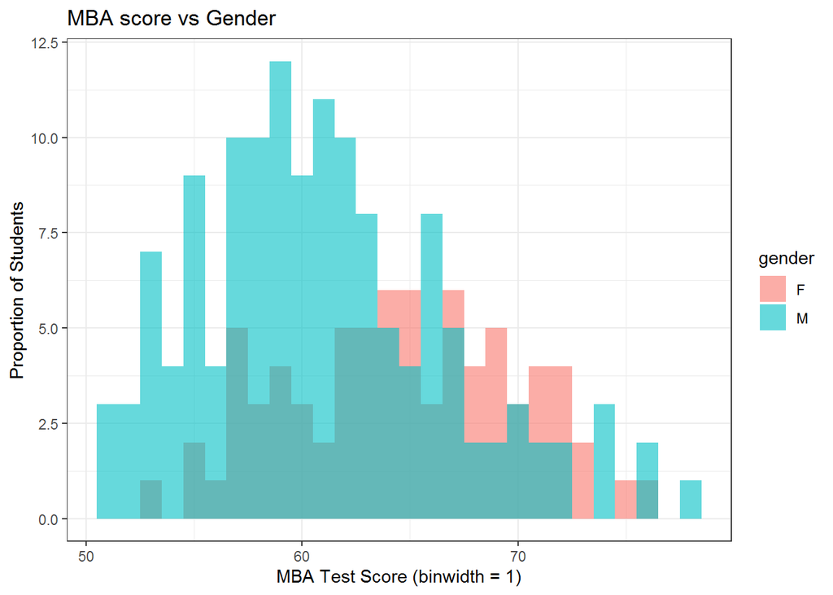

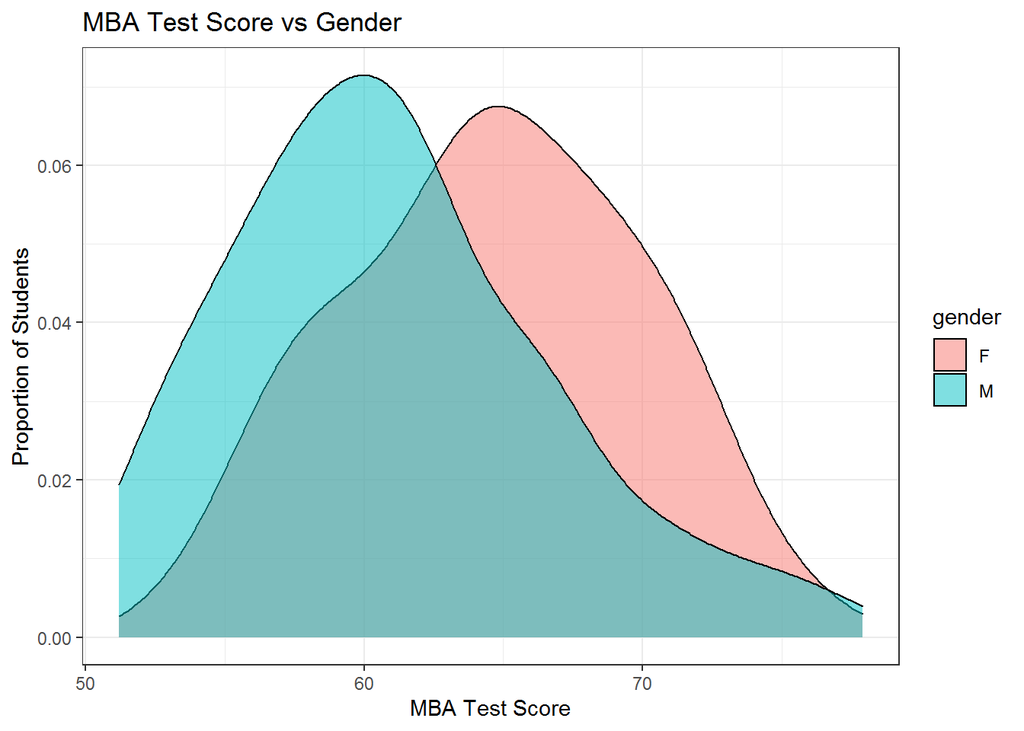

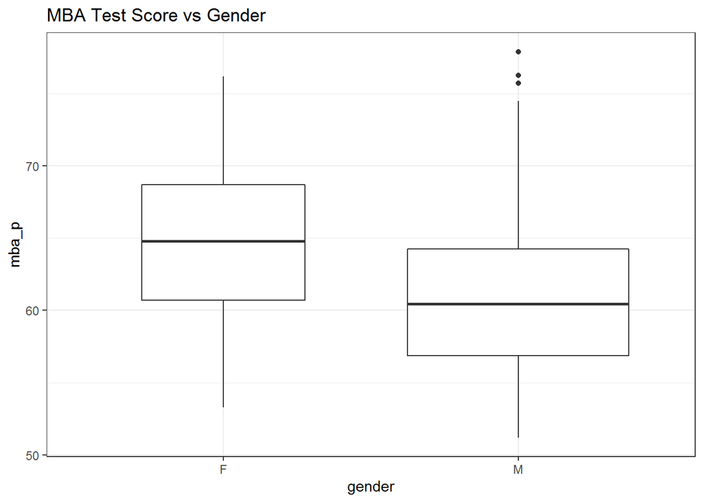

**Remark:** From the overlayed histogram, density plot, and box plot we see that MBA test scores for male students are skewed to the right, and the scores for the female students is skewed slightly to the left (almost symmetrical). The median score for female students is almost 65 and that for male students is 61. The box plot also shows some extremely high scores for male students as outliers from the trend observed. Therefore, it can be concluded that more female students performed better in the MBA test.

#### 0.2.1.23 How did students from each gender perform on the employment test?

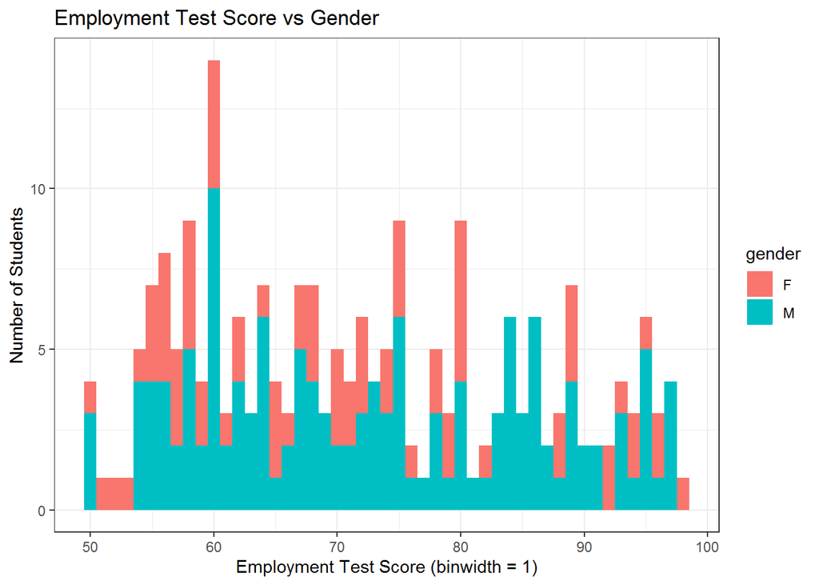

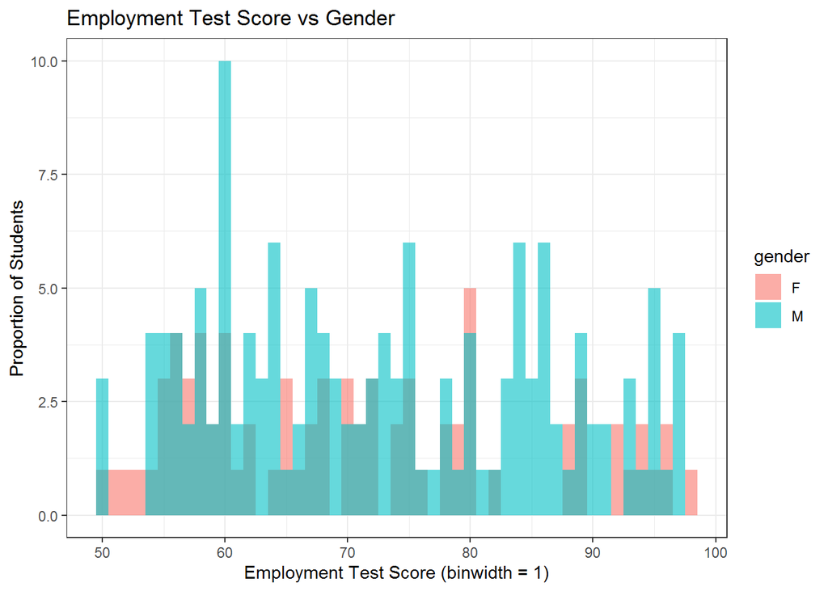

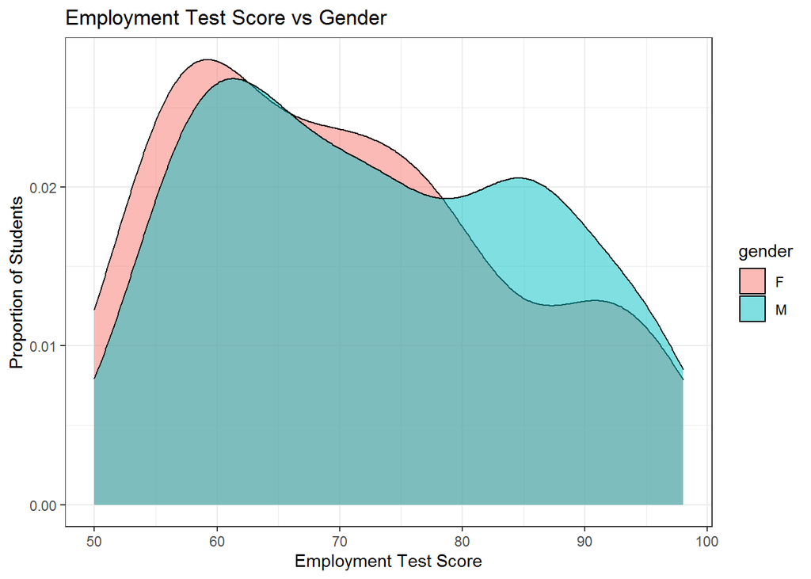

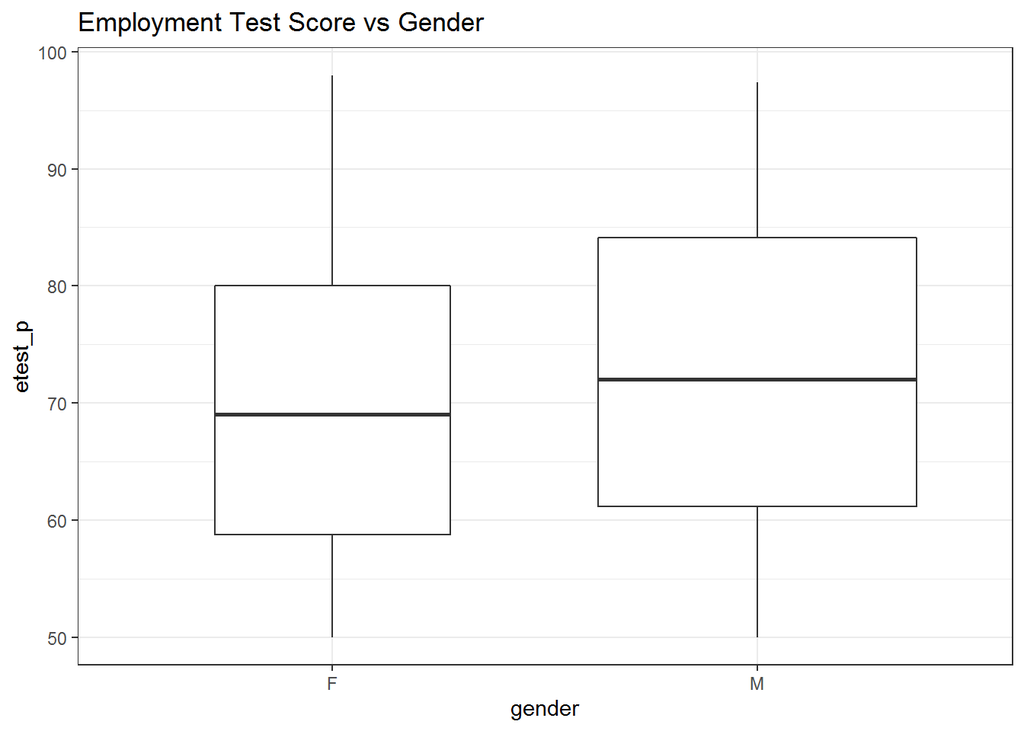

**Remark:** The density curves for employement test scores for both genders show multimodal distribution of the data. The blue density curve have two peaks, one around 60 and one around 85. The pink density curve have two peaks around 58 and 90, and a small plateau around 70. The prominent peaks for both curves overlap around the same regions, where the peaks around the lower scores (58 and 60) have higher density, and the peaks around the higher scores (85 and 90) have lower density. This corresponds to the possibility that students with work experience performed better at the employment test. The lower density for the higher scores is in agreement with the finding that fewer students have previous work experience. According to the box plot, median score for female students is around 69 and that for male students is around 72.

Therefore, it can be concluded that more male students performed better in the employment test.

#### 0.2.1.24 How did students from each gender perform on the degree test?

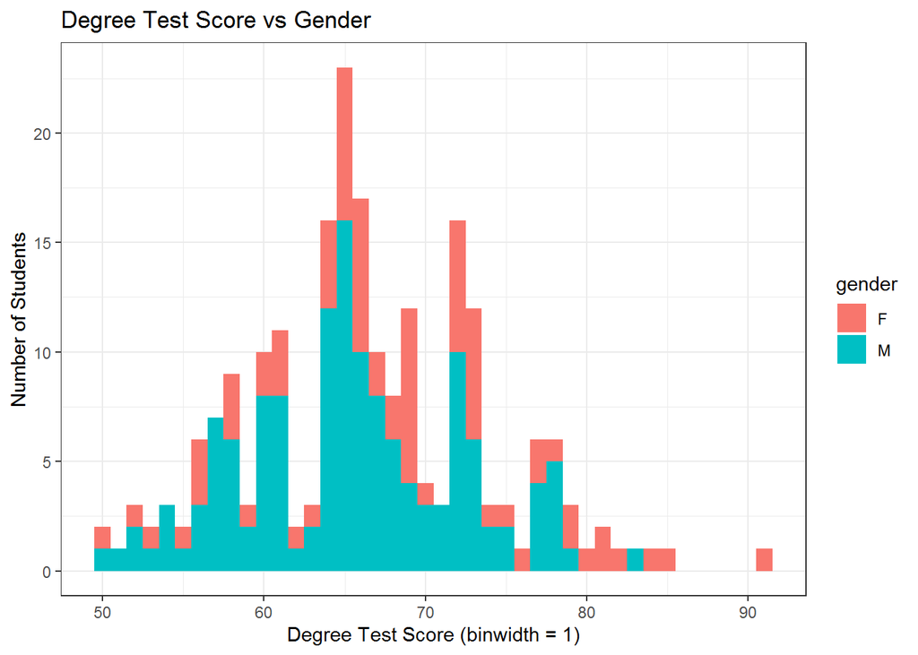

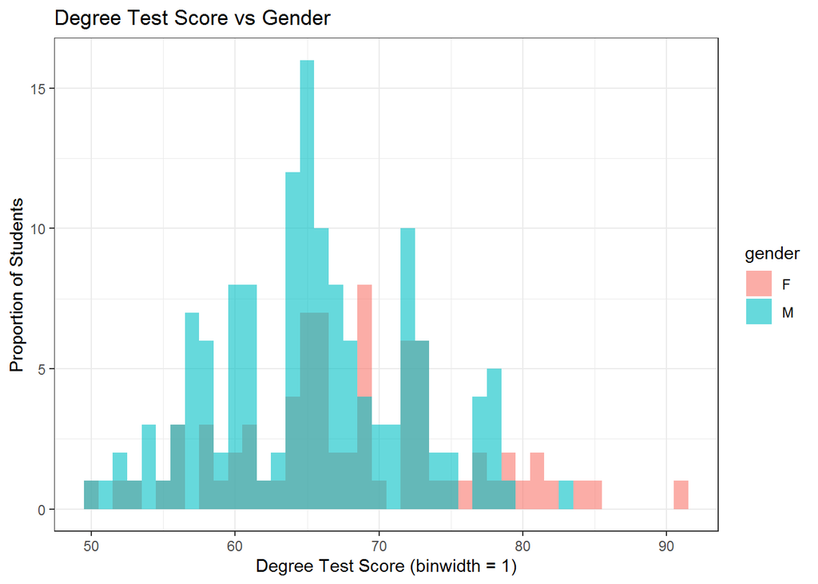

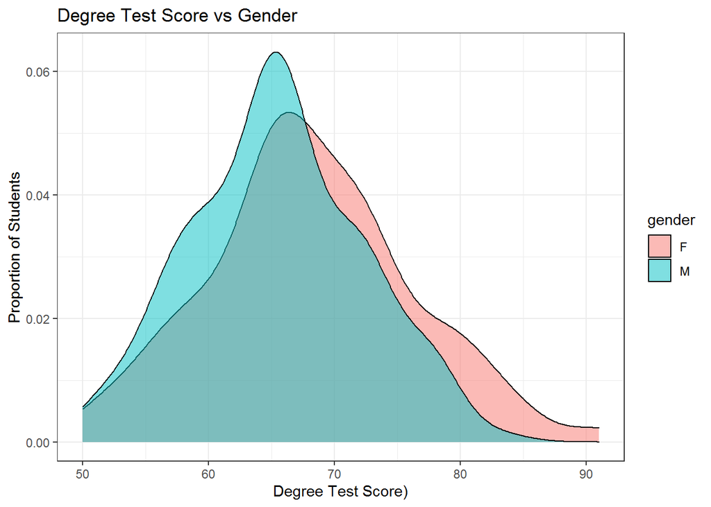

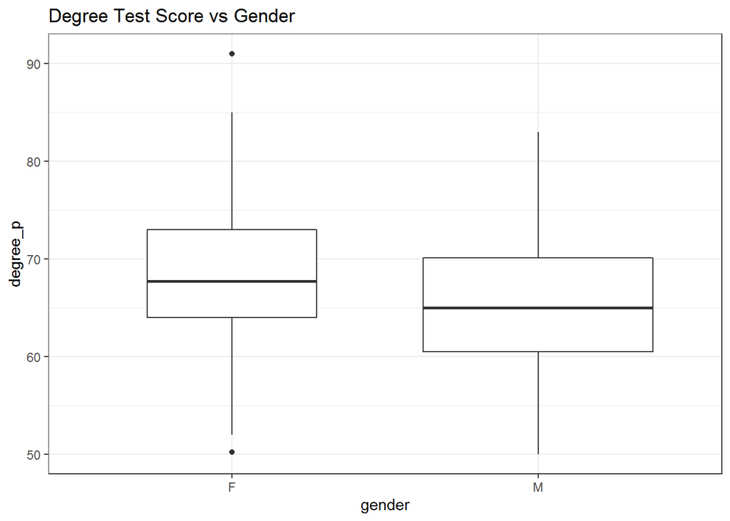

**Remark:** The density curves and box plot show that the degree test score distribution for male and female students is slightly skewed to the right. Median score for female students is around 67, and median score for male students is 65. It can be concluded that more female students performed better in the degree test.

#### 0.2.1.25 How did students from each gender perform on the higher secondary test?

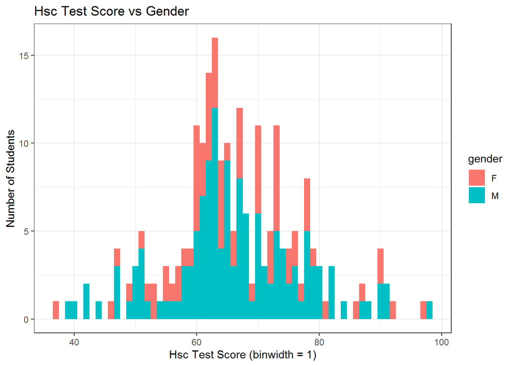

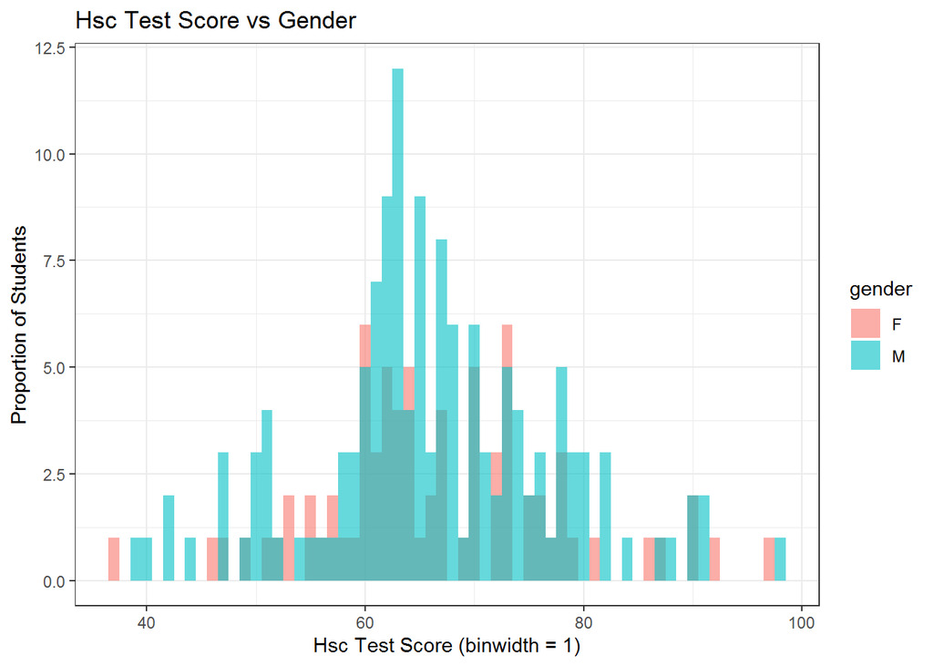

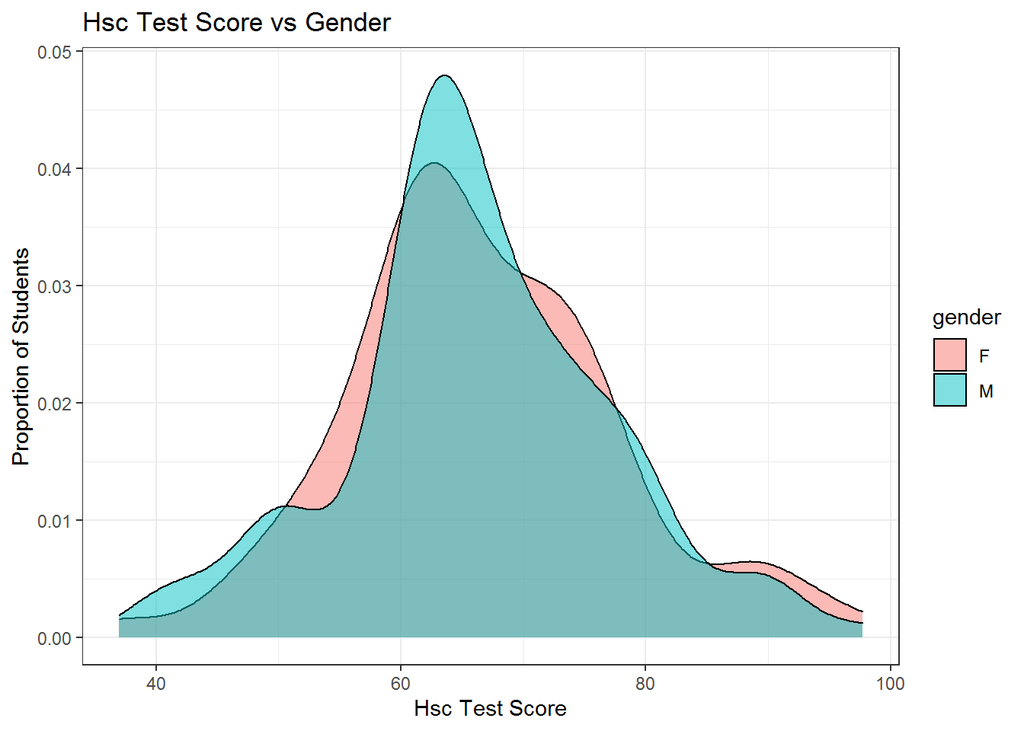

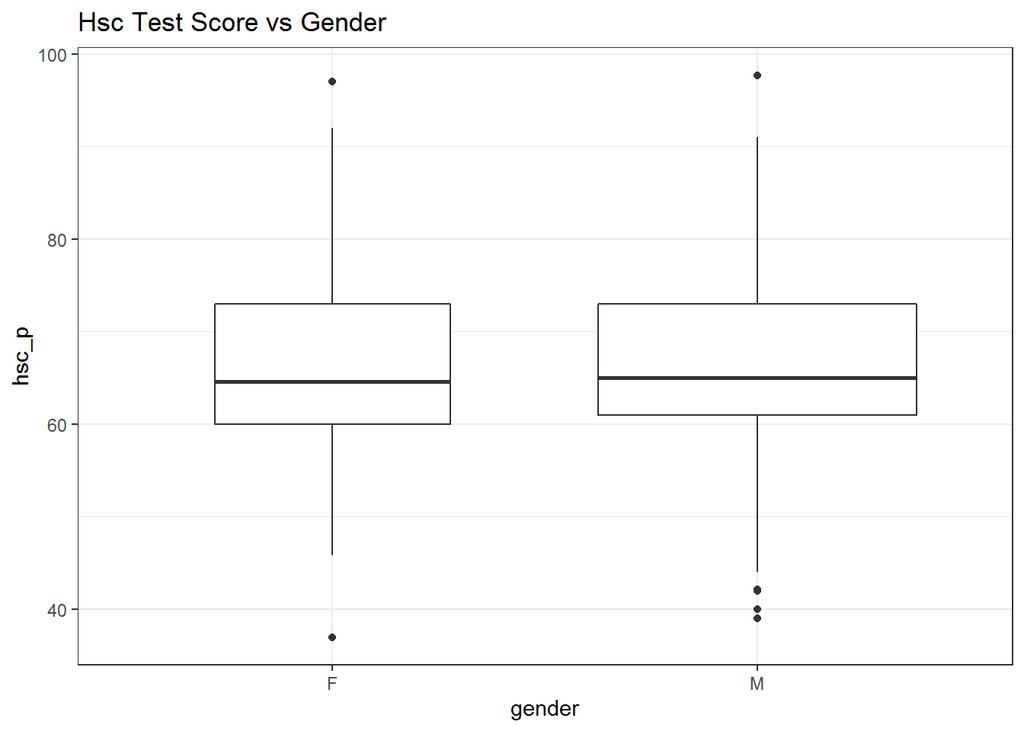

#### 0.2.1.26 How did students from each gender perform on the secondary test?

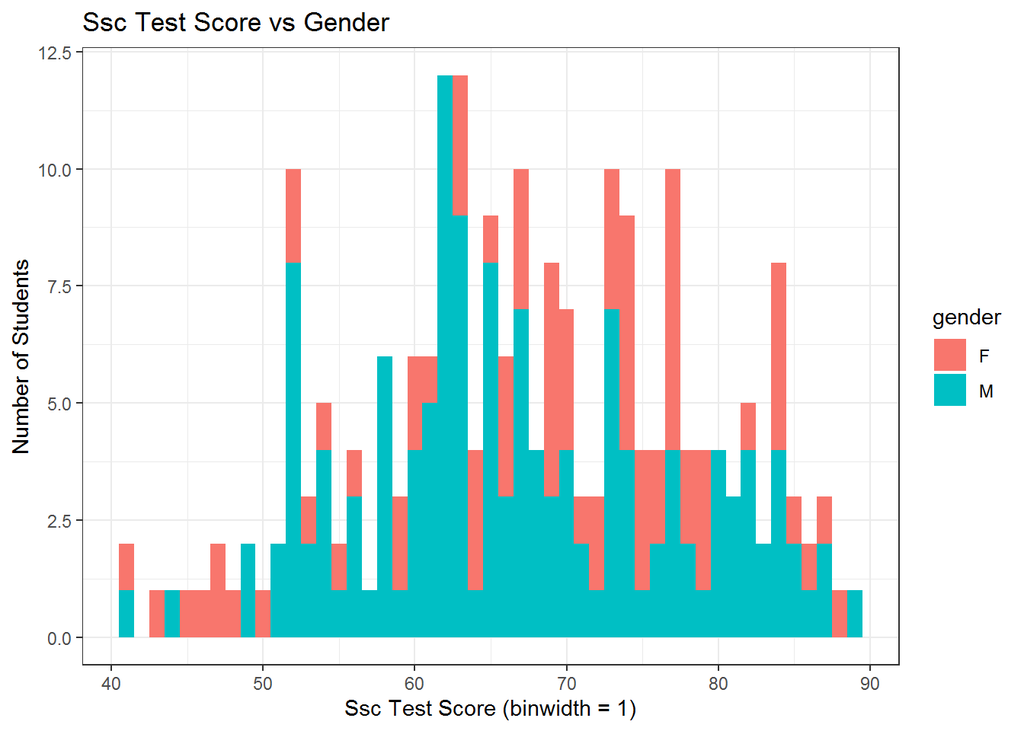

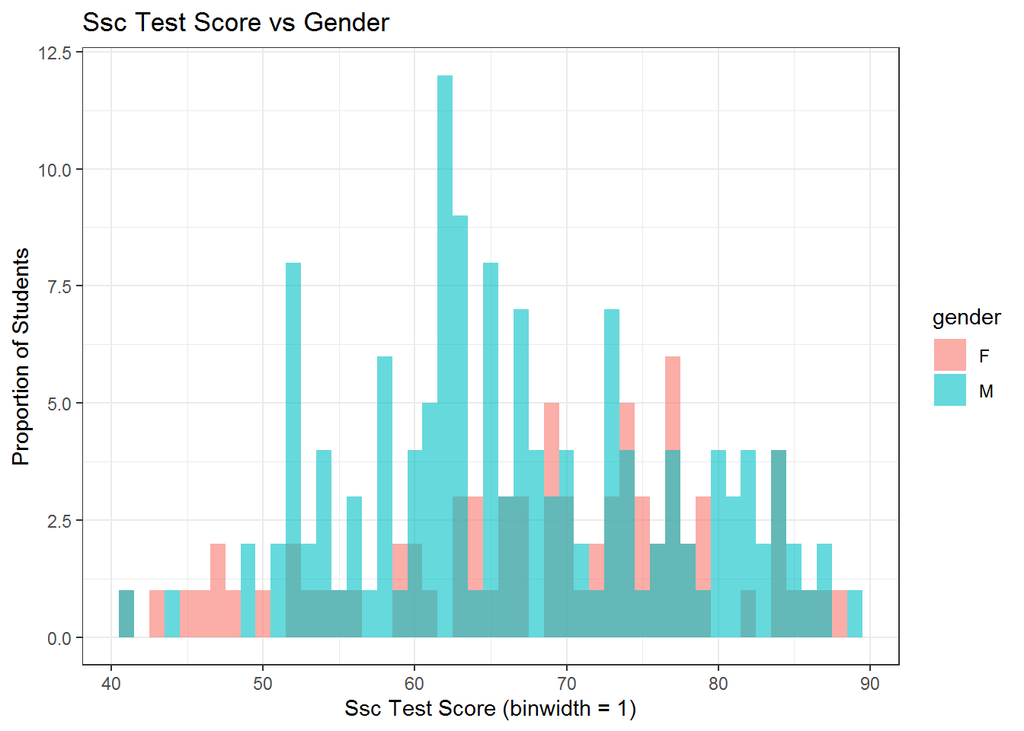

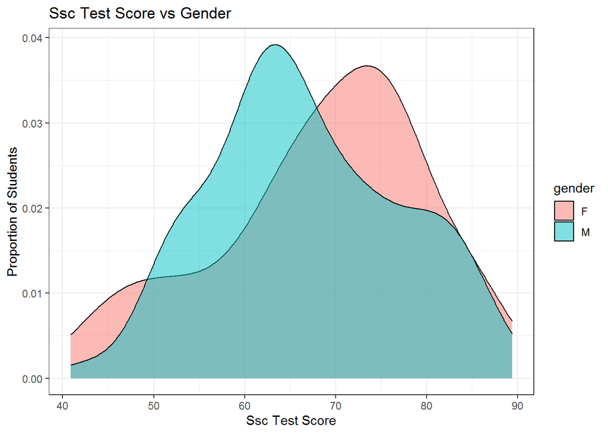

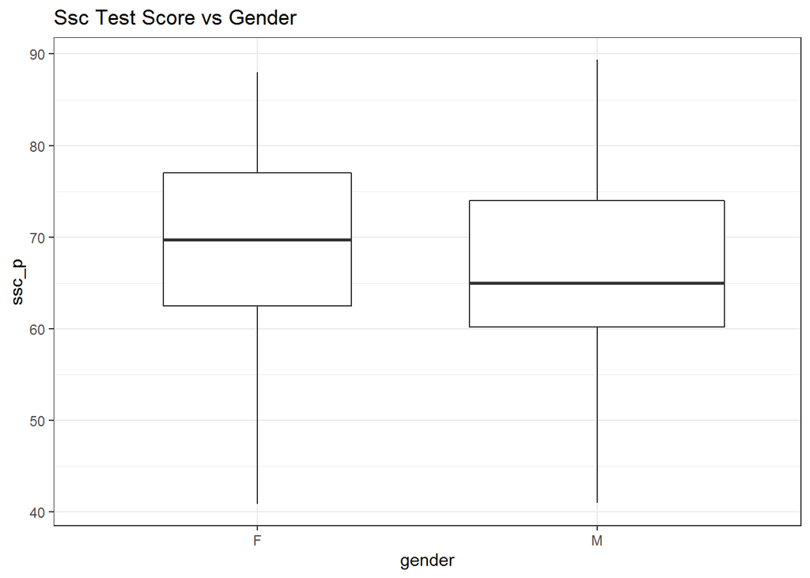

**Remark:** The density plot and box plot show that secondary school test scores for male students are skewed slightly to the right with a median score of 65. The test score for female students is skewed to the left with a median score of 70. It can be concluded that more female students performed better in the secondary school test.

*Visual analysis of the test scores based on gender shows that for the most part female students performed better in the academic tests. Male students performed better in the employment test because of a larger number of male students than female had work experience.*

### 0.2.2 Influence on Salary

#### 0.2.2.1 What is the numeric range of the salaries offered?

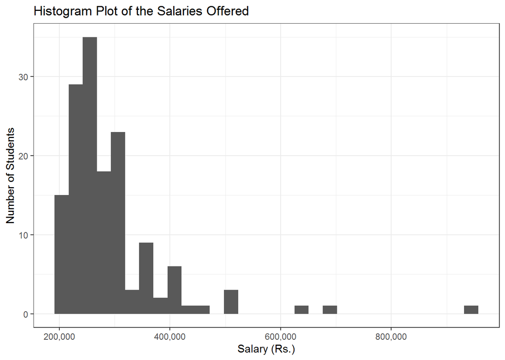

**Remark:** The salary offered ranges from roughly Rs.200,000 to Rs.950,000. And the median salary is around Rs.265,000.

#### 0.2.2.2 How does the salary for hired students vary based on their gender?

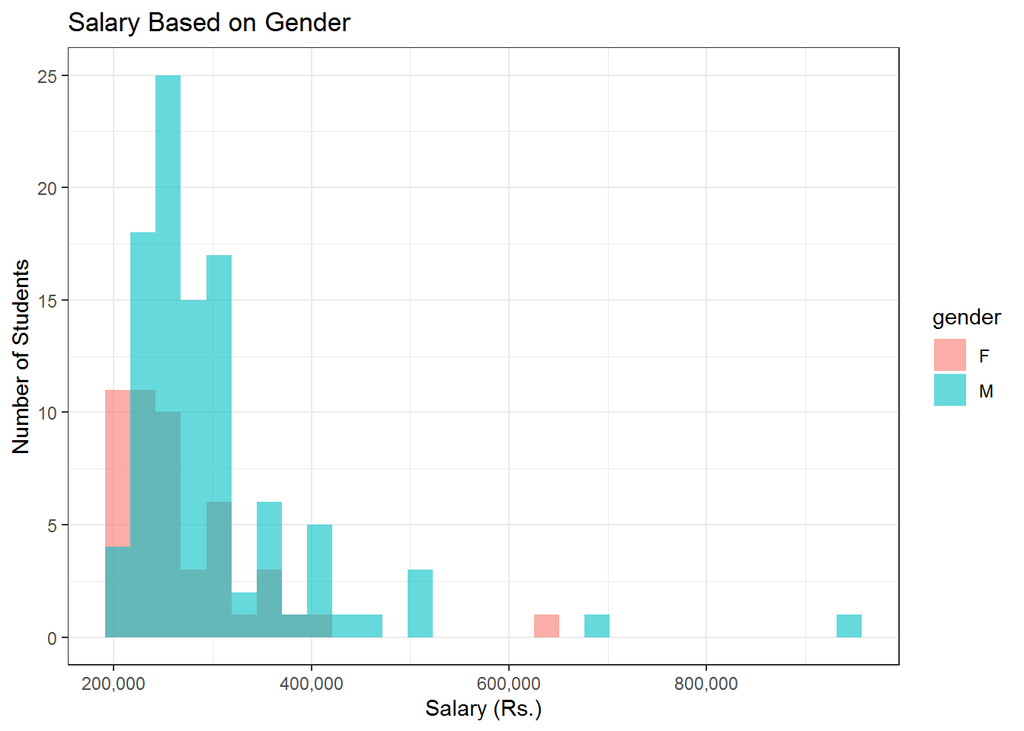

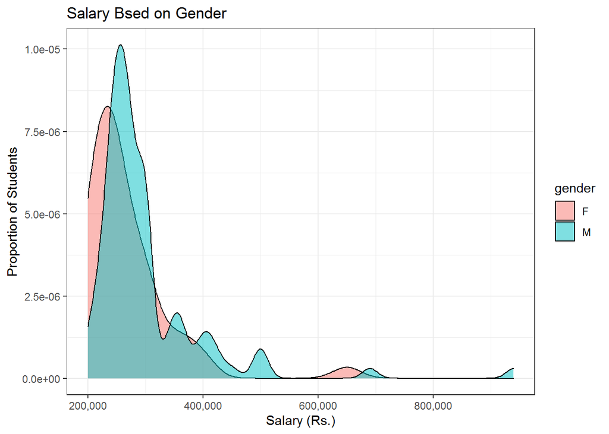

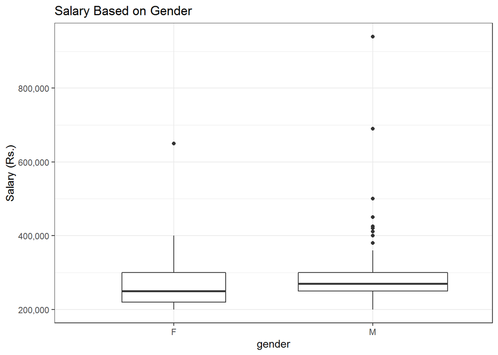

#### 0.2.2.3 How does the salary for hired students vary based on their MBA specialization?

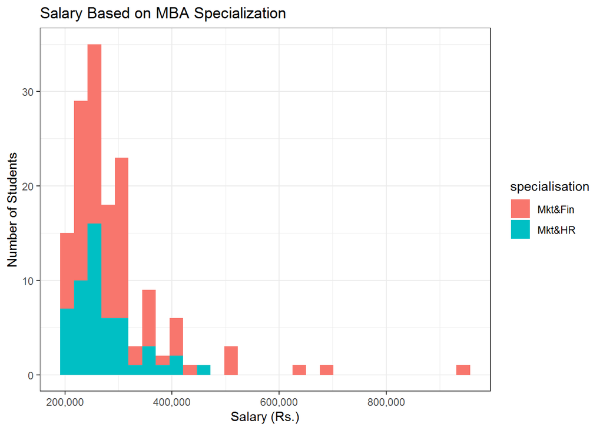

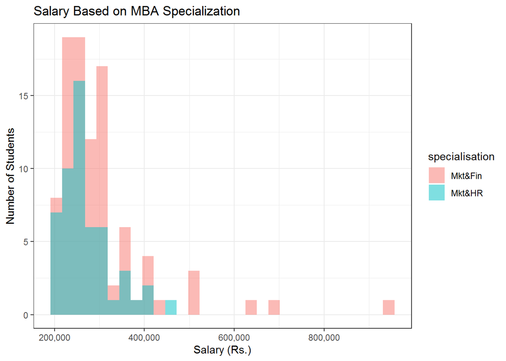

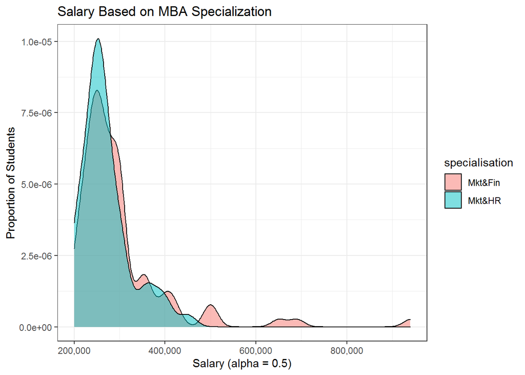

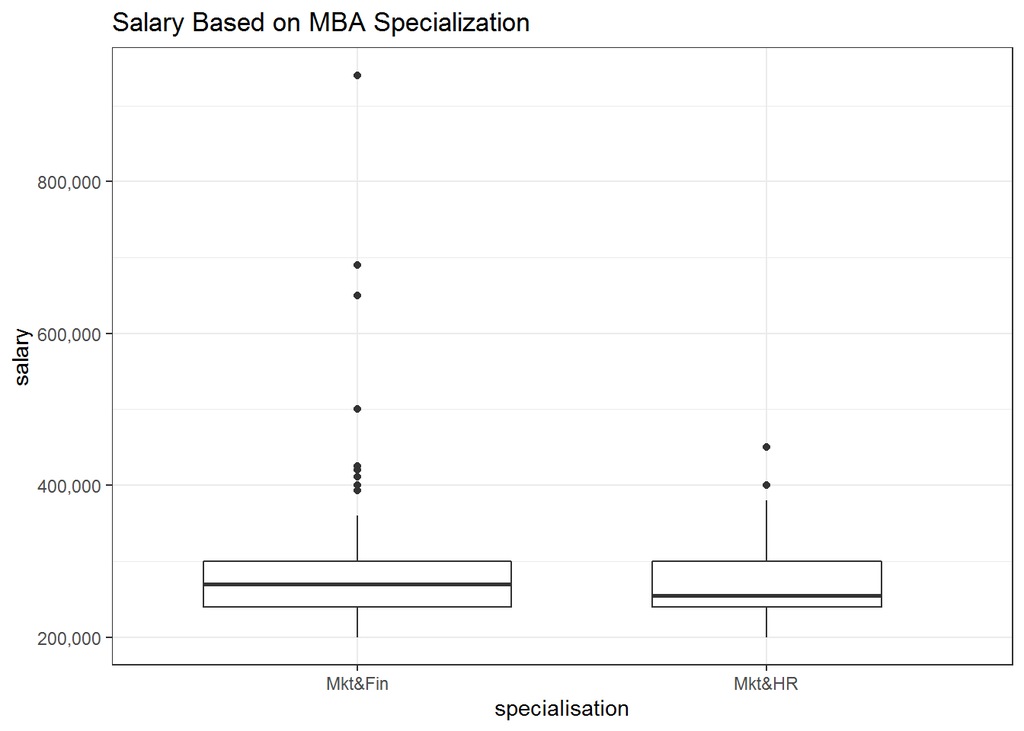

**Remark:** Based on the overlayed histogram and box plot we see that the median salary offered to placed students from Mkt&Fin are higher than that of Mkt&HR. We also see that really high salaries in the range Rs.500,000 - Rs.950,000 were offered to students in Mkt&Fin. Highest salary offered to students placed in Mkt&HR is approximately Rs.460,000.